# Inferential Analysis of Exponential Distribution through Simulation by CLT

Gowri Shankar

09/09/2015

## Overview

Exponential distribution is a process in which events occur continuously and independently at a constant average rate.

This is an inferential report on the simulation analysis conducted on exponential distribution data using central limit theorem. It proves theoretical mean and variance quoted above with simulated data.

## Simulations

Exponentially distributed data is generated using R’s **rexp** function. 3 kinds of simulations are done to prove theoretical mean **1/λ** and simulated mean converges.

- for 1000 iteration with **rate** parameter of **0.2** cumulative mean was calculated
- Simulation for 1000 iterations with 40 exponentials
- Law of Large Numbers test with 400 exponentials
- a histogram is drawn to show the density of distributed data is normal by portraying a bell curve

```r
nosims <- 1000;
lambda <- 0.2
n = 40
set.seed(123)
```

## Sample Mean vs Theoretical Mean(1000 Iterations)

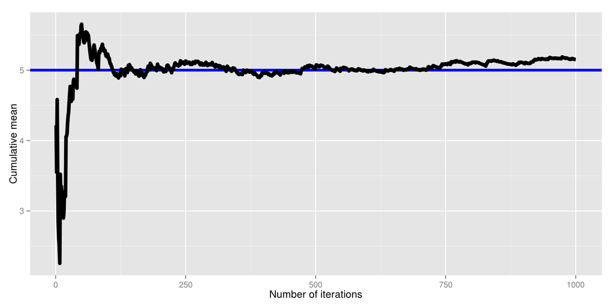

```r
means <- cumsum(rexp(nosims, lambda)) / (1  : nosims); library(ggplot2)
g <- ggplot(data.frame(x = 1 : nosims, y = means), aes(x = x, y = y))
g <- g + geom_hline(yintercept = 1/lambda,  color = I('blue'), size = 1.5) + geom_line(size = 2)
g <- g + labs(x = "Number of iterations", y = "Cumulative mean")
g
```

## Sample Mean vs Theoretical Mean(1000 Iterations of 40 exponentials)

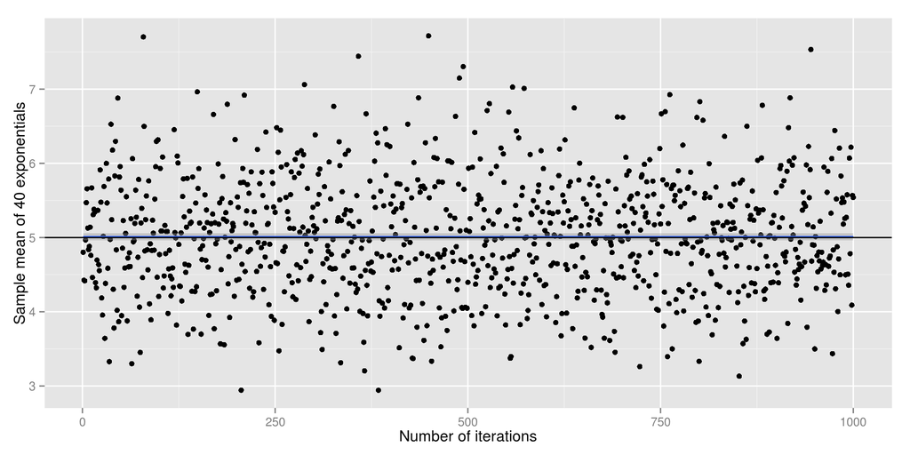

```r
sim_data = data.frame(x = sapply(1:nosims, function(x) { rexp(n, lambda) }))
means = data.frame(x = sapply(sim_data[, 1:nosims], mean))
qplot(x, y, data=data.frame(x = 1:nosims, y = means$x)) +
    geom_smooth() +
    geom_hline(yintercept = 1/lambda) +
    labs(x = "Number of iterations", y = "Sample mean of 40 exponentials")
```

Black line is theoretical mean and blue one is sample mean

## Law of Large Numbers(1000 Iterations of 400 exponentials)

No let us look at what happens when number of exponentials are 400 and iterated for 1000 times.

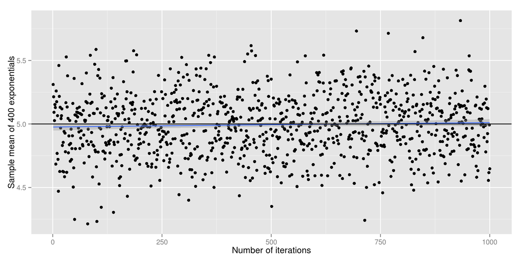

```r
means = data.frame(x = sapply(1:nosims, function(x) {
    mean(rexp(400, lambda))
}))
qplot(x, y, data=data.frame(x = 1:nosims, y = means$x)) +
    geom_smooth() +
    geom_hline(yintercept = 1/lambda) +
    labs(x = "Number of iterations", y = "Sample mean of 400 exponentials")
```

Above plot once again proves the sample mean converges at theoretical mean. Now the error is very less, distribution quite closer to **1/λ = 5**

## Sample Variance vs Theoretical Variance

Let us take Standard Deviation instead of Variance, so that our plots are uniform.

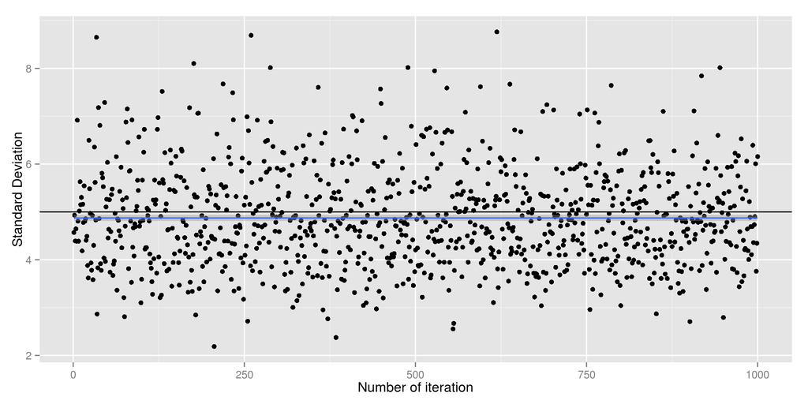

```r
sds = sapply(sim_data[, 1:nosims], sd)
qplot(x, y, data=data.frame(x = 1:nosims, y = sds)) + geom_smooth() + geom_hline(yintercept = 1/lambda) + labs(x = "Number of iteration", y = "Standard Deviation")
```

This plot also shows the data is dense around **1/λ = 5**

## Distribution

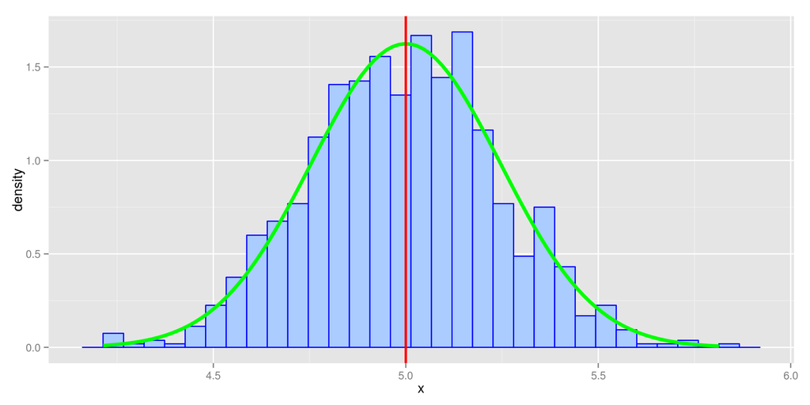

```r
ggplot(data = means, aes(x = x)) +
    geom_histogram(aes(y=..density..), fill = I('#aaccff'), color = I('blue')) +
    stat_function(fun = dnorm, arg = list(mean = 1/lambda, sd = sd(means$x)), color = I('green'), size = 1.5) +
    geom_vline(xintercept = 1/lambda, size = 1, color = I('red'))
```